# Análisis Exploratorio de Datos Meteorológicos en Plantas Solares

ANYELO RODRIGUEZ

2026-06-14

# 1 Introducción y Planteamiento del Problema

En la última década, la transición energética en Colombia ha impulsado la integración de Fuentes No Convencionales de Energía Renovable (FNCER) al Sistema Interconectado Nacional (SIN). Entre estas, la energía solar fotovoltaica juega un papel crucial. Sin embargo, la generación de energía solar es intrínsecamente variable e intermitente, ya que depende directamente de condiciones atmosféricas fluctuantes como la radiación y la temperatura.

Para garantizar la estabilidad de la red eléctrica, **XM**, como operador del mercado y coordinador del SIN, recopila diariamente datos meteorológicos a través del Informe Diario de Operación (IDO). Este conjunto de datos registra variables críticas como:

- la irradiación global,
- la irradiación sobre el panel,
- la temperatura ambiente
- la temperatura interna del panel
- diversas unidades de generación (`CodigoUnidadGeneracion`).

El problema radica en que los datos provenientes de sensores en campo suelen presentar anomalías operativas debido a fallas de calibración, pérdidas de conectividad o mantenimiento de las estaciones. Esto se traduce en registros duplicados, valores faltantes (NA) y lecturas atípicas (como temperaturas ambiente en 0°C en zonas de alta radiación). Si estos datos se utilizan sin una fase previa de curaduría, cualquier análisis descriptivo o modelo predictivo de eficiencia energética generará conclusiones sesgadas o decisiones erróneas en el despacho de energía.

Por lo tanto, este proyecto aborda la necesidad de realizar un **Análisis Exploratorio de Datos** y un flujo riguroso de **Limpieza de Datos** sobre el dataset meteorológico de XM.

# 2 Objetivos del Proyecto

## 2.1 Objetivo General

Desarrollar e implementar un flujo de trabajo reproducible para el análisis exploratorio y la limpieza de datos del dataset meteorológico de plantas solares de XM, garantizando la calidad de la información para su posterior uso en la toma de decisiones y modelos predictivos.

## 2.2 Objetivos Específicos

1. **Identificar y tratar anomalías de estructura:** Detectar y eliminar registros duplicados y gestionar los valores faltantes (NA) mediante criterios técnicos de exclusión o imputación.
2. **Analizar la distribución estadística:** Evaluar el comportamiento descriptivo (tendencia central, variabilidad y dispersión) de las variables cuantitativas de irradiación y temperatura ambiente.
3. **Identificar comportamientos atípicos y patrones por unidad:** Detectar valores atípicos (outliers) mediante el uso de diagramas de caja (boxplots) y determinar el Top 10 de las unidades de generación fotovoltaica con mayor variabilidad o registros críticos en el sistema.

# 3 Configuración del Entorno y Carga de Datos

Preparamos el entorno de trabajo cargando las librerías necesarias para la manipulación, limpieza y visualización de los datos.

```r
list.files("../Datos") # Verificar que archivos están en el proyecto
```

```
## [1] "MeteorologíalocalenPlantasSolaresba58e638-917b-4896-b47c-56a2509b4de1.csv"
```

```r
# Carga de librerías esenciales
library(readr)
library(dplyr)
library(ggplot2)
library(writexl)
```

```r
data_solar <- read_csv("../Datos/MeteorologíalocalenPlantasSolaresba58e638-917b-4896-b47c-56a2509b4de1.csv")
```

# 4 Descripción del Dataset y Selección de Variables

se realiza la caracterización del conjunto de datos y se justifican las variables analíticas que fundamentan este estudio.

## 4.1 Caracterización de la estructura de datos

El conjunto de datos provisto por **XM S.A. E.S.P.** contiene las siguientes especificaciones estructurales:

| Nombre de la Columna | Descripción Técnica | Tipo de Dato en R |
| --- | --- | --- |
| **Fecha** | Registro cronológico del periodo de observación. | Fecha (`Date` / `character`) |
| **CodigoUnidadGeneracion** | Identificador alfanumérico único asignado a cada central fotovoltaica. | Texto (`character`) |
| **IrradiacionPanel** | Magnitud de la irradiación solar incidente sobre la superficie del plano inclinado (W/m²). | Numérico (`double`) |
| **TemperaturaPanel** | Registro térmico directo sobre las celdas del módulo fotovoltaico (°C). | Numérico (`double`) |
| **IrradiacionGlobal** | Irradiación solar global horizontal registrada en la estación de referencia (W/m²). | Numérico (`double`) |
| **TemperaturaAmbiente** | Temperatura termodinámica del aire circundante en el emplazamiento de la planta (°C). | Numérico (`double`) |

## 4.2 Justificación técnica de las variables seleccionadas

El análisis exploratorio y multifactorial se centrará en los siguientes componentes:

1. **Variable Cuantitativa:** `TemperaturaAmbiente`. Variable continua fundamental cuyo comportamiento térmico incide inversamente proporcional en la eficiencia nominal de las celdas de silicio.
2. **Variable Cualitativa:** `CodigoUnidadGeneracion`. Variable categórica nominal que opera como factor de agrupación para el análisis comparativo inter-unidades.

# 5 Exploración Inicial de Estructura y Dimensiones

Previo a la aplicación de los algoritmos de depuración, se efectúa un reconocimiento de la geometría del dataset y del tipo de almacenamiento de las variables mediante funciones de diagnóstico estadístico.

```r
# Evaluación de los tipos de datos y la estructura interna del objeto
str(data_solar)
```

```
## spc_tbl_ [4,546 × 6] (S3: spec_tbl_df/tbl_df/tbl/data.frame)
##  $ Fecha                 : Date[1:4546], format: "2025-12-14" "2025-12-14" ...
##  $ CodigoUnidadGeneracion: chr [1:4546] "Uns21219" "Uns19573" "Uns07303" "Uns19731" ...
##  $ IrradiacionPanel      : num [1:4546] NA 540 513 406 427 ...
##  $ TemperaturaPanel      : num [1:4546] NA 49.6 36.7 NA 38.1 ...
##  $ IrradiacionGlobal     : num [1:4546] NA 442 354 380 379 ...
##  $ TemperaturaAmbiente   : num [1:4546] NA 31.9 30 0 22.2 ...
##  - attr(*, "spec")=
##   .. cols(
##   ..   Fecha = col_date(format = ""),
##   ..   CodigoUnidadGeneracion = col_character(),
##   ..   IrradiacionPanel = col_double(),
##   ..   TemperaturaPanel = col_double(),
##   ..   IrradiacionGlobal = col_double(),
##   ..   TemperaturaAmbiente = col_double()
##   .. )
##  - attr(*, "problems")=<pointer: 0x0000011999e79bb0>
```

```r
# Resumen estadístico descriptivo preliminar del dataset original
summary(data_solar)
```

```
##      Fecha            CodigoUnidadGeneracion IrradiacionPanel TemperaturaPanel
##  Min.   :2025-09-01   Length   :4546         Min.   :  0.0    Min.   : 0.00
##  1st Qu.:2025-10-03   N.unique :  42         1st Qu.:291.9    1st Qu.:32.40
##  Median :2025-11-04   N.blank  :   0         Median :408.6    Median :38.79
##  Mean   :2025-11-02   Min.nchar:   8         Mean   :396.7    Mean   :36.14
##  3rd Qu.:2025-12-04   Max.nchar:   8         3rd Qu.:517.8    3rd Qu.:42.81
##  Max.   :2026-01-01                          Max.   :883.0    Max.   :99.00
##                                              NAs    :968      NAs    :1057
##  IrradiacionGlobal TemperaturaAmbiente
##  Min.   :   0.14   Min.   : 0.00
##  1st Qu.: 274.49   1st Qu.:25.90
##  Median : 381.44   Median :28.12
##  Mean   : 364.78   Mean   :26.45
##  3rd Qu.: 467.84   3rd Qu.:30.01
##  Max.   :1194.00   Max.   :46.90
##  NAs    :1072      NAs    :976
```

# 6 Exploración de los Datos

```r
tail(data_solar) # últimos datos
```

```
## # A tibble: 6 × 6
##   Fecha      CodigoUnidadGeneracion IrradiacionPanel TemperaturaPanel
##   <date>     <chr>                             <dbl>            <dbl>
## 1 2025-12-05 Uns07300                           484.             38.0
## 2 2025-12-05 Uns18128                           468.             42.3
## 3 2025-12-05 Uns16743                           633.             43.7
## 4 2025-12-05 Uns53072                           425.             36.4
## 5 2025-12-05 Uns10100                           411.             36.9
## 6 2025-12-05 Uns19470                            NA               0
## # ℹ 2 more variables: IrradiacionGlobal <dbl>, TemperaturaAmbiente <dbl>
```

```r
head(data_solar) # primeros datos
```

```
## # A tibble: 6 × 6
##   Fecha      CodigoUnidadGeneracion IrradiacionPanel TemperaturaPanel
##   <date>     <chr>                             <dbl>            <dbl>
## 1 2025-12-14 Uns21219                            NA              NA
## 2 2025-12-14 Uns19573                           540.             49.6
## 3 2025-12-14 Uns07303                           513.             36.7
## 4 2025-12-14 Uns19731                           406.             NA
## 5 2025-12-14 Uns19464                           427.             38.1
## 6 2025-12-14 Uns18125                           288.             37.0
## # ℹ 2 more variables: IrradiacionGlobal <dbl>, TemperaturaAmbiente <dbl>
```

## 6.1 Dimensiones del archivo.

```r
dim(data_solar)
```

```
## [1] 4546    6
```

## 6.2 Diagramas de cajas y bigotes

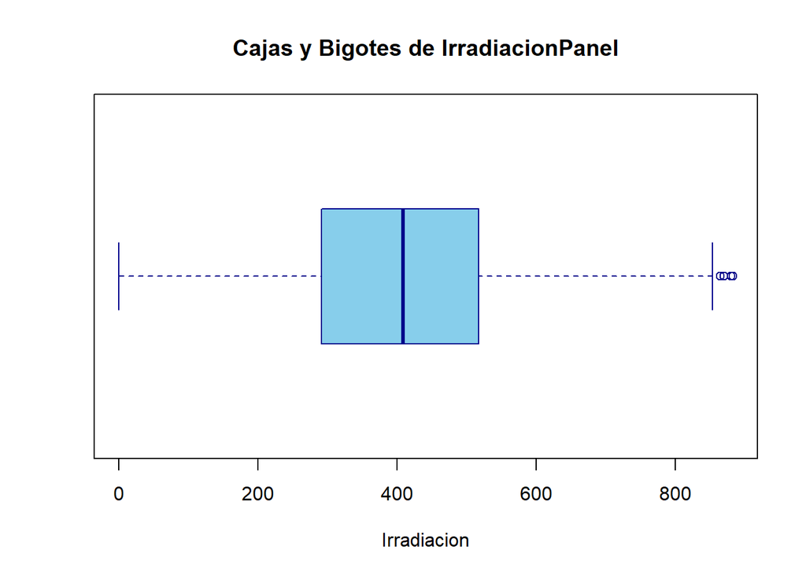

```r
library(ggplot2)

boxplot(
  data_solar$IrradiacionPanel,
  horizontal = TRUE,
  col = "skyblue",
  border = "darkblue",
  main = "Cajas y Bigotes de IrradiacionPanel",
  xlab = "Irradiacion"
)
```

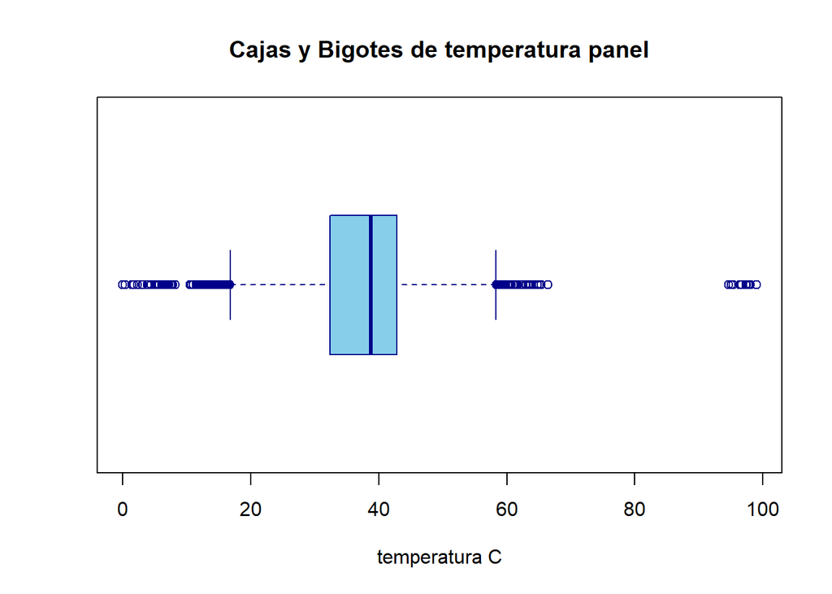

```r
library(ggplot2)

boxplot(
  data_solar$TemperaturaPanel,
  horizontal = TRUE,
  col = "skyblue",
  border = "darkblue",
  main = "Cajas y Bigotes de temperatura panel",
  xlab = "temperatura C"
)
```

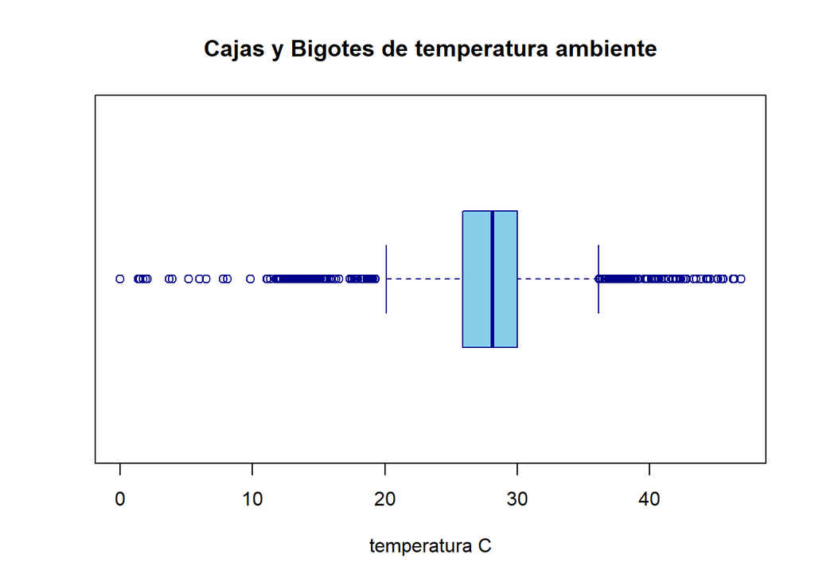

```r
library(ggplot2)

boxplot(
  data_solar$TemperaturaAmbiente,
  horizontal = TRUE,
  col = "skyblue",
  border = "darkblue",
  main = "Cajas y Bigotes de temperatura ambiente",
  xlab = "temperatura C"
)
```

## 6.3 Diagrama de Distribución (Histograma y Densidad)

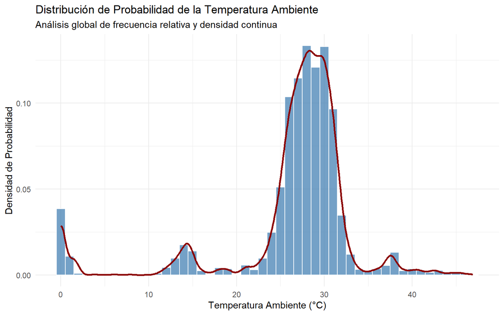

```r
# Construcción del histograma acoplado con curva de densidad kernel
ggplot(data_solar, aes(x = TemperaturaAmbiente)) +
  geom_histogram(aes(y = after_stat(density)), binwidth = 1, fill = "steelblue", color = "white", alpha = 0.75) +
  geom_density(color = "darkred", linewidth = 1) +
  labs(
    title = "Distribución de Probabilidad de la Temperatura Ambiente",
    subtitle = "Análisis global de frecuencia relativa y densidad continua",
    x = "Temperatura Ambiente (°C)",
    y = "Densidad de Probabilidad"
  ) +
  theme_minimal()
```

# 7 Limpieza de datos

## 7.1 Valores faltantes

Valores perdidos en todo el data frame

```r
# Número total de datos perdidos en el dataframe
total_na <- sum(is.na(data_solar))

print(paste("Total de datos perdidos:", total_na))
```

```
## [1] "Total de datos perdidos: 4073"
```

Total de datos perdidos 4073.

Valores faltantes por columnas

```r
library(dplyr)


# Número de datos perdidos por columna
na_por_columna <- colSums(is.na(data_solar))

# Crear un dataframe con los resultados

tabla_na <- data.frame(
  Columna = names(na_por_columna), # obtiene los nombres de las columnas
  Datos_Perdidos = na_por_columna # contiene la cantidad de NA por variable
)

# tabla_na
# Agregar una fila con el total de datos perdidos

tabla_na <- rbind(tabla_na, data.frame(Columna = "Total", Datos_Perdidos = total_na)) # rbind() agrega filas a una tabla, una fila con Total y datos perdidos


#tabla_na

# Ordenar la tabla en orden descendente
tabla_na_ordenada <- tabla_na %>%
  filter(Columna != "Total") %>%  # Excluir la fila "Total"
  arrange(desc(Datos_Perdidos)) %>%  # Ordenar de mayor a menor
  rbind(data.frame(Columna = "Total", Datos_Perdidos = total_na))  # Agregar la fila "Total" al final

tabla_na_ordenada
```

```
##                                       Columna Datos_Perdidos
## IrradiacionGlobal           IrradiacionGlobal           1072
## TemperaturaPanel             TemperaturaPanel           1057
## TemperaturaAmbiente       TemperaturaAmbiente            976
## IrradiacionPanel             IrradiacionPanel            968
## Fecha                                   Fecha              0
## CodigoUnidadGeneracion CodigoUnidadGeneracion              0
## 1                                       Total           4073
```

## 7.2 Se eliminan las filas con datos faltantes

```r
filas_originales <- nrow(data_solar)

# Limpieza
data_solar <- data_solar %>%
  na.omit() %>%
  distinct()

print(paste("Filas originales:", filas_originales, "| Filas después de limpiar:", nrow(data_solar)))
```

```
## [1] "Filas originales: 4546 | Filas después de limpiar: 3201"
```

##Verificacion si hay datos faltantes

```r
total_na <- sum(is.na(data_solar))

# Número de datos perdidos por columna
na_por_columna <- colSums(is.na(data_solar))

# Crear un dataframe con los resultados

tabla_na <- data.frame(
  Columna = names(na_por_columna), # obtiene los nombres de las columnas
  Datos_Perdidos = na_por_columna # contiene la cantidad de NA por variable
)

# tabla_na
# Agregar una fila con el total de datos perdidos

tabla_na <- rbind(tabla_na, data.frame(Columna = "Total", Datos_Perdidos = total_na)) # rbind() agrega filas a una tabla, una fila con Total y datos perdidos


#tabla_na

# Ordenar la tabla en orden descendente
tabla_na_ordenada <- tabla_na %>%
  filter(Columna != "Total") %>%  # Excluir la fila "Total"
  arrange(desc(Datos_Perdidos)) %>%  # Ordenar de mayor a menor
  rbind(data.frame(Columna = "Total", Datos_Perdidos = total_na))  # Agregar la fila "Total" al final

tabla_na_ordenada
```

```
##                                       Columna Datos_Perdidos
## Fecha                                   Fecha              0
## CodigoUnidadGeneracion CodigoUnidadGeneracion              0
## IrradiacionPanel             IrradiacionPanel              0
## TemperaturaPanel             TemperaturaPanel              0
## IrradiacionGlobal           IrradiacionGlobal              0
## TemperaturaAmbiente       TemperaturaAmbiente              0
## 1                                       Total              0
```

## 7.3 Total datos Duplicados

```r
sum(duplicated(data_solar))
```

```
## [1] 0
```

## 7.4 Mostrar datos duplicados

```r
data_solar[duplicated(data_solar), ]
```

```
## # A tibble: 0 × 6
## # ℹ 6 variables: Fecha <date>, CodigoUnidadGeneracion <chr>,
## #   IrradiacionPanel <dbl>, TemperaturaPanel <dbl>, IrradiacionGlobal <dbl>,
## #   TemperaturaAmbiente <dbl>
```

No se observan datos duplicados, ya son series de tiempo.

## 7.5 Datos repetidos sin tener en cuenta el ID

```r
data_sin <-(data_solar[ , -2])
head(data_sin)
```

```
## # A tibble: 6 × 5
##   Fecha      IrradiacionPanel TemperaturaPanel IrradiacionGlobal
##   <date>                <dbl>            <dbl>             <dbl>
## 1 2025-12-14            540.             49.6               442.
## 2 2025-12-14            513.             36.7               354.
## 3 2025-12-14            427.             38.1               379.
## 4 2025-12-14            288.             37.0               285.
## 5 2025-12-14             58.9            37.3               389.
## 6 2025-12-14            601.              7.22              528.
## # ℹ 1 more variable: TemperaturaAmbiente <dbl>
```

Averiguar el número total de filas repetidas

```r
sum(duplicated(data_sin))
```

```
## [1] 0
```

Mostrar las filas repetidas

```r
data_sin[duplicated(data_sin), ]
```

```
## # A tibble: 0 × 5
## # ℹ 5 variables: Fecha <date>, IrradiacionPanel <dbl>, TemperaturaPanel <dbl>,
## #   IrradiacionGlobal <dbl>, TemperaturaAmbiente <dbl>
```

## 7.6 Estadísticas Descriptivas de Temperatura Ambiente

```r
media_temp <- mean(data_solar$TemperaturaAmbiente)
mediana_temp <- median(data_solar$TemperaturaAmbiente)

# R no tiene una función base para la moda, creamos esta rápida:
obtener_moda <- function(v) {
   uniqv <- unique(v)
   uniqv[which.max(tabulate(match(v, uniqv)))]
}
moda_temp <- obtener_moda(data_solar$TemperaturaAmbiente)

cat("Medidas de Tendencia Central para Temperatura Ambiente:\n",
    "Media:", round(media_temp, 2), "°C\n",
    "Mediana:", round(mediana_temp, 2), "°C\n",
    "Moda:", moda_temp, "°C\n")
```

```
## Medidas de Tendencia Central para Temperatura Ambiente:
##  Media: 27.34 °C
##  Mediana: 28.12 °C
##  Moda: 25.75 °C
```

## 7.7 Top 10 Unidades de Generación por Temperatura

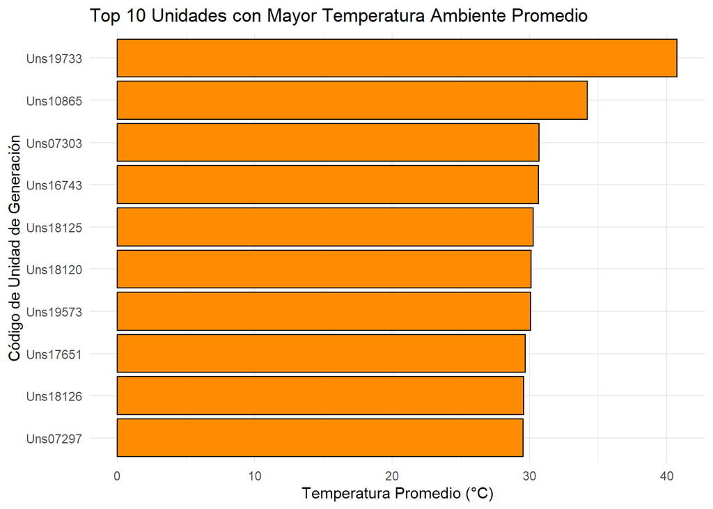

```r
# Extraer el Top 10
top10_unidades <- data_solar %>%
  group_by(CodigoUnidadGeneracion) %>%
  summarise(Temp_Promedio = mean(TemperaturaAmbiente)) %>%
  arrange(desc(Temp_Promedio)) %>%
  head(10)

# Gráfico del Top 10
ggplot(top10_unidades, aes(x = reorder(CodigoUnidadGeneracion, Temp_Promedio), y = Temp_Promedio)) +
  geom_col(fill = "darkorange", color = "black") +
  coord_flip() + # Voltea el gráfico para leer bien los códigos
  labs(
    title = "Top 10 Unidades con Mayor Temperatura Ambiente Promedio",
    x = "Código de Unidad de Generación",
    y = "Temperatura Promedio (°C)"
  ) +
  theme_minimal()
```

## Relación entre Irradiación y Temperatura del Panel

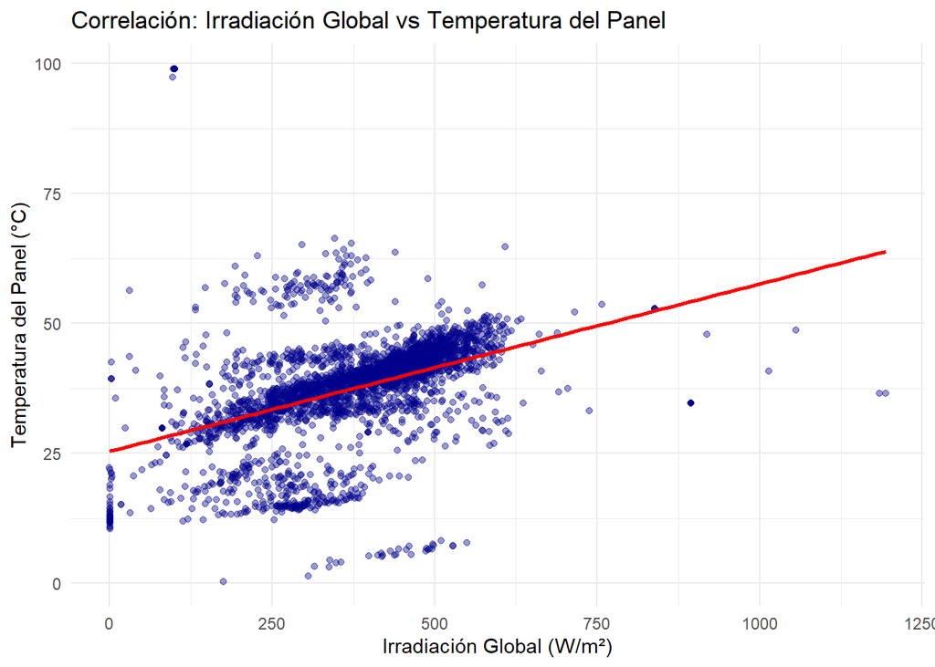

```r
ggplot(data_solar, aes(x = IrradiacionGlobal, y = TemperaturaPanel)) +
  geom_point(alpha = 0.4, color = "darkblue") +
  geom_smooth(method = "lm", color = "red", se = FALSE) +
  labs(
    title = "Correlación: Irradiación Global vs Temperatura del Panel",
    x = "Irradiación Global (W/m²)",
    y = "Temperatura del Panel (°C)"
  ) +
  theme_minimal()
```

## 7.8 Evolución de la Temperatura Promedio en el Tiempo

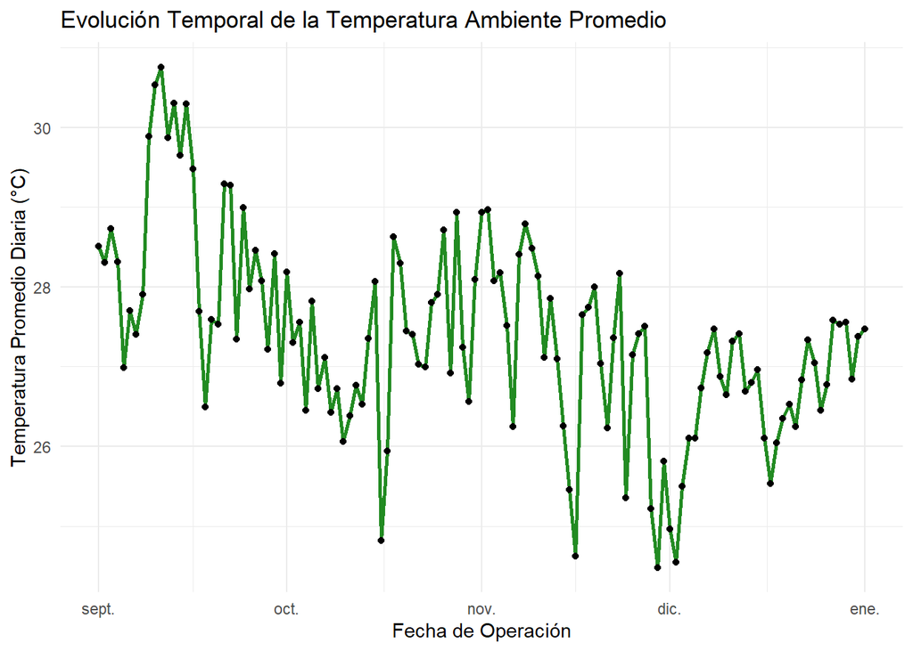

```r
# Agrupar por fecha para ver el comportamiento diario global
tendencia_diaria <- data_solar %>%
  group_by(Fecha) %>%
  summarise(Temp_Promedio_Dia = mean(TemperaturaAmbiente))

ggplot(tendencia_diaria, aes(x = Fecha, y = Temp_Promedio_Dia)) +
  geom_line(color = "forestgreen", size = 1) +
  geom_point(color = "black", size = 1.5) +
  labs(
    title = "Evolución Temporal de la Temperatura Ambiente Promedio",
    x = "Fecha de Operación",
    y = "Temperatura Promedio Diaria (°C)"
  ) +
  theme_minimal()
```

# Conclusiones